# Netflix EDA

Nurul Hafizah Zaini

2025-06-30

## Introduction

### Dataset

The dataset was obtained from an open-source Kaggle platform. This dataset consists of listings of all the movies and tv shows available on Netflix, along with details such as - cast, directors, ratings, release year, duration, etc.

### Project Context

The project aims to explore trends on type distribution, genres over time, and missing values.

## Dataset Overview

### Dataset head

```
## # A tibble: 6 × 12
##   show_id type    title    director cast  country date_added release_year rating
##   <chr>   <chr>   <chr>    <chr>    <chr> <chr>   <chr>             <dbl> <chr>
## 1 s1      Movie   Dick Jo… Kirsten… <NA>  United… September…         2020 PG-13
## 2 s2      TV Show Blood &… <NA>     Ama … South … September…         2021 TV-MA
## 3 s3      TV Show Ganglan… Julien … Sami… <NA>    September…         2021 TV-MA
## 4 s4      TV Show Jailbir… <NA>     <NA>  <NA>    September…         2021 TV-MA
## 5 s5      TV Show Kota Fa… <NA>     Mayu… India   September…         2021 TV-MA
## 6 s6      TV Show Midnigh… Mike Fl… Kate… <NA>    September…         2021 TV-MA
## # ℹ 3 more variables: duration <chr>, listed_in <chr>, description <chr>
```

### Dataset summary

```
##    show_id              type              title             director
##  Length:8807        Length:8807        Length:8807        Length:8807
##  Class :character   Class :character   Class :character   Class :character
##  Mode  :character   Mode  :character   Mode  :character   Mode  :character
##
##
##
##      cast             country           date_added         release_year
##  Length:8807        Length:8807        Length:8807        Min.   :1925
##  Class :character   Class :character   Class :character   1st Qu.:2013
##  Mode  :character   Mode  :character   Mode  :character   Median :2017
##                                                           Mean   :2014
##                                                           3rd Qu.:2019
##                                                           Max.   :2021
##     rating            duration          listed_in         description
##  Length:8807        Length:8807        Length:8807        Length:8807
##  Class :character   Class :character   Class :character   Class :character
##  Mode  :character   Mode  :character   Mode  :character   Mode  :character
##
##
##
```

### Dataset dimension

```
## [1] 8807   12
```

### Columns’ names

```
##  [1] "show_id"      "type"         "title"        "director"     "cast"
##  [6] "country"      "date_added"   "release_year" "rating"       "duration"
## [11] "listed_in"    "description"
```

### Check for missing Value

```
##      show_id         type        title     director         cast      country
##            0            0            0         2634          825          831
##   date_added release_year       rating     duration    listed_in  description
##           10            0            4            3            0            0
```

## Exploratory Data Analysis (EDA)

### Movies vs Tv Shows

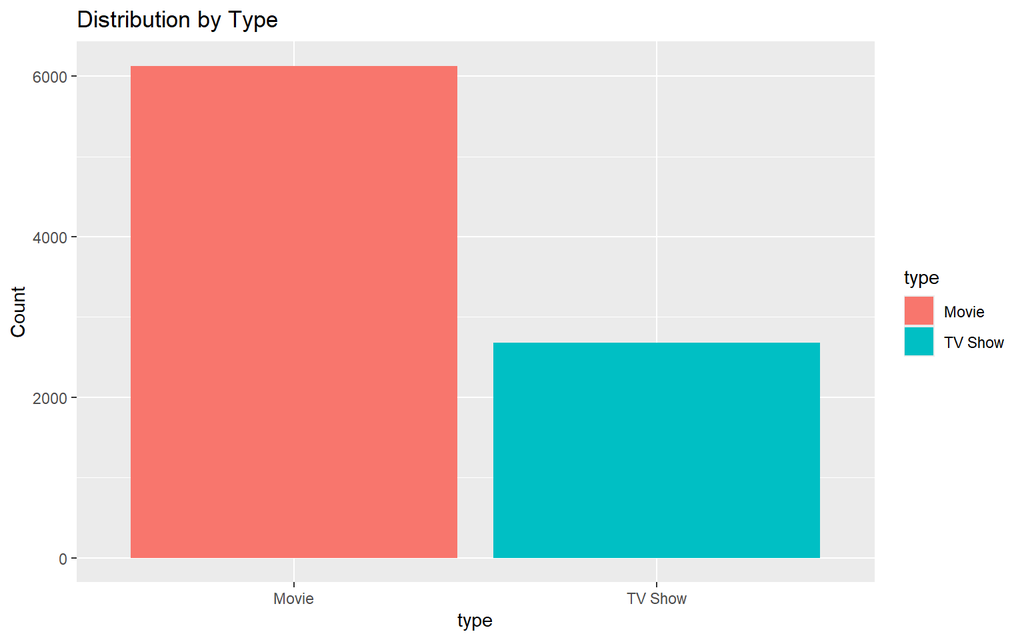

Key insight: The majority of Netflix catalog is Movie type. It makes up about 2/3 of the Netflix titles.